# Week6

Sarfaraz Ahmed

July 20, 2017

# Lab 6: Worldwide Trends in Internet Usage

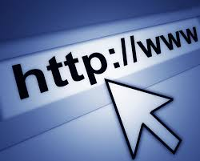

The World Bank is a data collection of information on all the world’s countries. Data is collected by country, and include items such as total population, CO2 emissions, and the number of mobile device subscriptions. We will examine some of the trends in this dataset and interpret the parameters of the fitted models to best describe the change over time.

Primary Research Question

What model best describes the first decade of internet usage (1990-1999) in the United States? Which model is a better long-term fit?

problem 3 points possible (graded) Check the Data

Let’s begin by examining our data in R.

1. Open RStudio. Make sure you’ve installed the current version of the SDSFoundations package.
2. Type library(SDSFoundations) This will automatically load the data for the labs. 3.Type world <- WorldBankData This will assign the data to your Workspace.
3. Look at the spreadsheet view of the data to answer the following questions.

Alternatively, you can use follow the steps in the “Importing a Data Frame” R tutorial video, and use the WorldBankData.csv file. (Right-click and “Save As.”) Make sure to name the dataframe “world” when importing.

1. Open RStudio.
2. Click on “Import Dataset” button at the top of the workspace window. Choose “from text file.”
3. Click on the location of the WorldBankData.csv file you just downloaded.
4. Click on the WorldBankData.csv file. Then, click Upload.
5. Look at the spreadsheet view of the data to answer the following questions.

```r
library(SDSFoundations)

world <- WorldBankData
```

1a) What is the first “Low Income” country in the dataset?

Afghanistan correct 1b) What was the rural population of Aruba in 1970? (Report without commas)

29164 correct 29164 1c) When was the first year Australia had data on the number of mobile device subscriptions? (Subscriptions more than 0)

1987 correct 1987 Submit You have used 1 of 1 attempt Some problems have options such as save, reset, hints, or show answer. These options follow the Submit button.

Show Answer Correct (3/3 points) Review problem 4/4 points (graded) Check the Variables of Interest

Let’s find the variables we need to answer the question.

2a) Which variable tells us the number of internet users in a specific year? The variable name in the dataset is:

correctinternet.users 2b) What type of variable is this?

correctquantitative 2c) Which variable tells us when the number of internet users was recorded? The variable name in the dataset is:

correctyear 2d) What type of variable is this?

correctquantitative Click here for a video explanation of how to answer this question. Submit You have used 1 of 1 attempt Some problems have options such as save, reset, hints, or show answer. These options follow the Submit button.

Show Answer Answers are displayed within the problem Review problem 2/2 points (graded) Reflect on the Method

Which method should we be using for this analysis and why?

3a) What statistic helps us determine how well a particular model fits the data?

Variance R-squared correct Mean 3b) In this lab, we will calculate residuals after fitting both an exponential and a logistic model to a set of data. What is a residual?

A residual is the difference between a predicted value and the actual observed value. correct A residual is the average distance of a data point to the line of best fit. A residual is a statistic that tells you how much variation is explained by the model. Submit You have used 1 of 1 attempt Some problems have options such as save, reset, hints, or show answer. These options follow the Submit button.

Primary Research Question

What model best describes the first decade of internet usage (1990-1999) in the United States? Which model is a better long-term fit?

Breakdown Your Analysis

Let’s break this analysis into its required steps:

1. Create a subset of the dataset that contains only the information for the United States.
2. Create a subset of the US data that contains only the years 1990 to 1999.
3. Use a function to fit both an exponential and a logistic model to the data.
4. Using each model, predict the number of internet users in 2006.
5. Compare the size of the residuals for 2006 to determine which model appears to have better long-term fit.

Note: In this lab, you will be creating three new subsets of data by constraining the original world dataset. The names of these three datasets are shown in the table below. A brief description of each is also provided to help you navigate the R code.

name description of dataset us contains only the USA data from the world dataset us_select contains only the USA data for the years 1990 and beyond  
us_select_10 contains only the USA data for the years 1990 - 1999 Here is the code you will use:

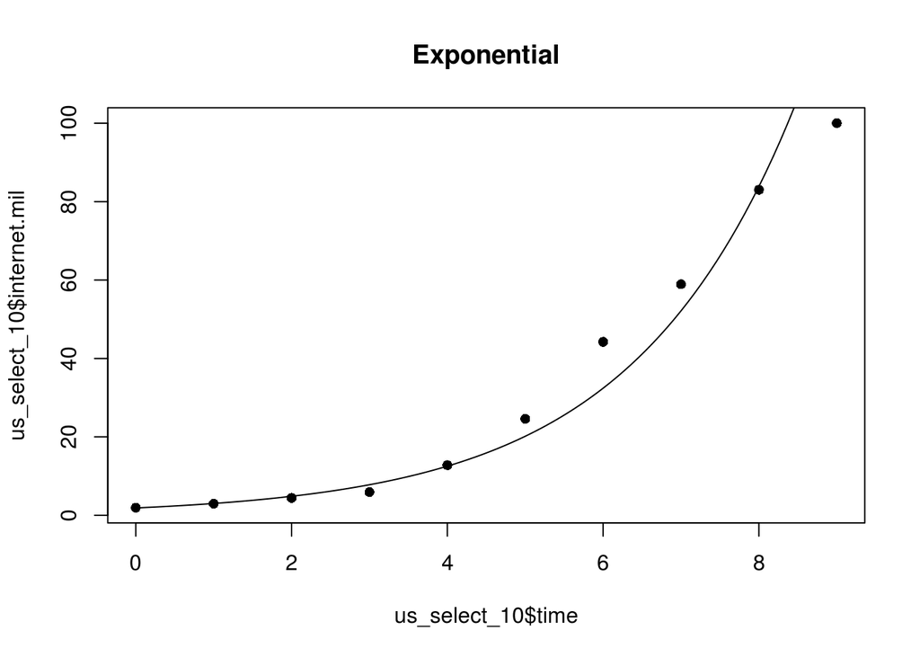

```
## Exponential Fit
##  a =  1.87184
##  b =  1.60845
##  R-squared =  0.98266
```

```r
# Subset data for just the United States and name the new data frame "us"
us <- world[world$Country.Code == "USA",]

# Select the years from 1990 and name the new data frame "us_select"
us_select <- us[us$year >= 1990, ]

# Create a new variable in our datset called internet.mil to make the number of users more interpretable (into millions)
us_select$internet.mil <- us_select$internet.users / 1000000

# Create a new variable in our dataset called time that represents "years since 1990"
us_select$time <- us_select$year - 1990

# Select the first 10 years (from 1990 to 1999) and name the new data frame "us_select_10"
us_select_10 <- us_select[us_select$time < 10,]

# Use a function to fit an exponential and logistic model for 1990-1999
expFit(us_select_10$time, us_select_10$internet.mil)
```

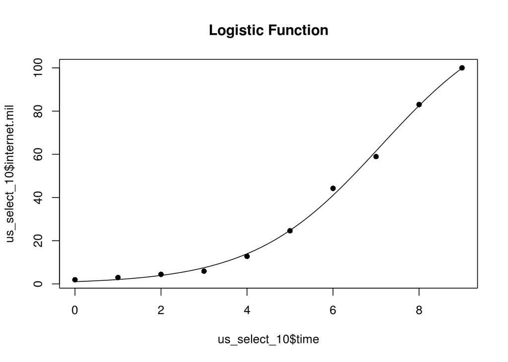

```
## Logistic Fit
##  C =  127.7935
##  a =  121.4
##  b =  1.96391
##  R-squared =  0.99802
```

```r
logisticFit(us_select_10$time, us_select_10$internet.mil)
```

```r
# Based on the prior model parameters, predict the number of internet users in 2006
e <- expFitPred(us_select_10$time, us_select_10$internet.mil, 16)
```

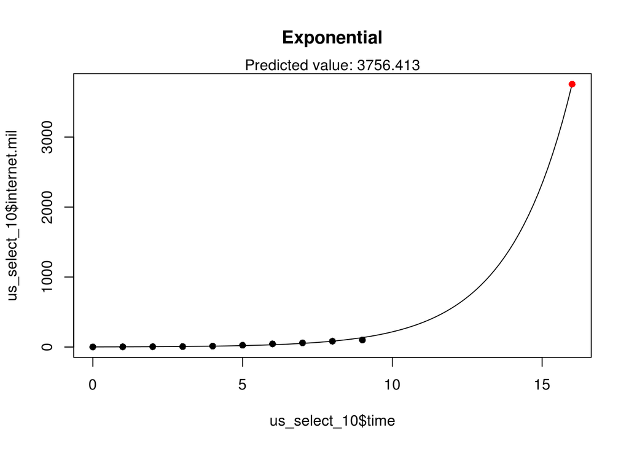

```r
l <- logisticFitPred(us_select_10$time, us_select_10$internet.mil, 16)
```

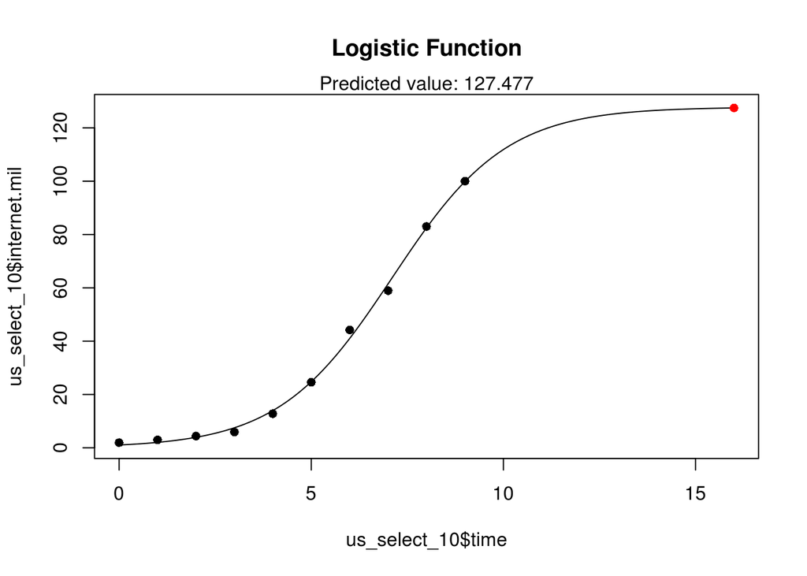

problem 1/1 point (graded) 1) In both of these models, what does Year 0 correspond to?

1990 correct 2012 1995 2000 Submit You have used 1 of 1 attempt Some problems have options such as save, reset, hints, or show answer. These options follow the Submit button.

Show Answer Correct (1/1 point) Review problem 1/1 point (graded) 2) Which functions will you use to fit exponential and logistic models to the data?

internet.mil() us_select expFit() and logisticFit() correct exp(model) and log(model) Submit You have used 1 of 1 attempt Some problems have options such as save, reset, hints, or show answer. These options follow the Submit button.

Show Answer Correct (1/1 point) Review problem 1/1 point (graded) 3) What will be the value of “us_select$time” for 2006?

6 16 correct 90 2006 Submit You have used 1 of 1 attempt Some problems have options such as save, reset, hints, or show answer. These options follow the Submit button.

Show Answer problem 1/1 point (graded) 4) In 1990, the number of internet users in the US was 1,958,863. What will be the value of “us_select$internet.mil” for 1990 after this line of code is run?

# Create a new variable in our dataset called internet.mil to make the number of users more interpretable (into millions)

`us_select$internet.mil <- us_select$internet.users / 1000000`

19.58863 1.958863 correct 1958,863 195.8863 Submit You have used 1 of 1 attempt Some problems have options such as save, reset, hints, or show answer. These options follow the Submit button.

Show Answer problem 1/1 point (graded) 5) Suppose we wanted to create a subset of data that contained only Belgium entries that were from 1990 and onward. What error was made in the code below? (Notice that R does not report some types of errors, making it very important to check your data as you go.)

`world <- WorldBankData` `belgium <- world[world$Country == 'Belgium',]` `recent_belgium <- world[world$year >= 1990,]`

The “Country” variable has only 3 letter entries. We pulled our data from the wrong dataset in the second line. We pulled our data from the wrong dataset in the third line. correct There is not a “Country” variable in the dataset to use. Submit You have used 1 of 1 attempt Some problems have options such as save, reset, hints, or show answer. These options follow the Submit button.

Primary Research Question

What model best describes the first decade of internet usage (1990-1999) in the United States? Which model is the best long-term fit?

Conduct the Analysis in R

1. Type or copy the script from the Prepare for the Analysis section into the Script window of R.
2. Select the portion of the code you wish to run, then press “ctrl+ enter.”
3. Output can be found in the Console window.

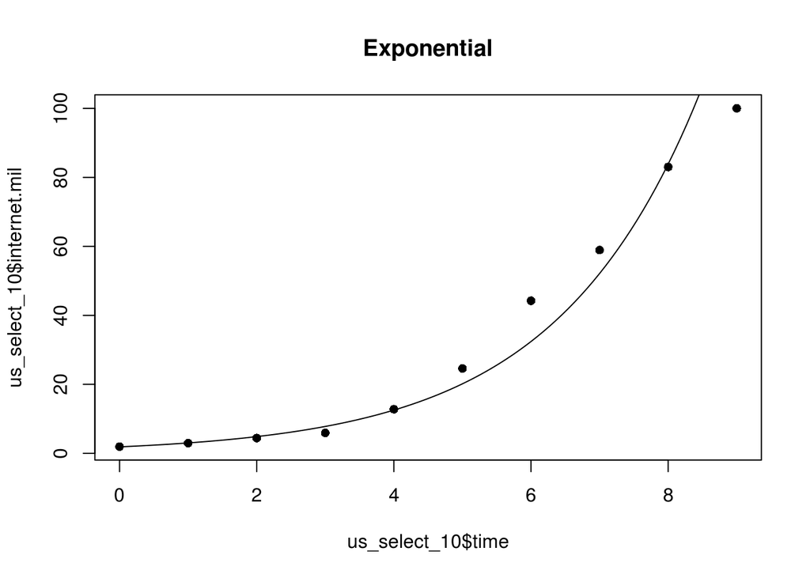

```
## Exponential Fit
##  a =  1.87184
##  b =  1.60845
##  R-squared =  0.98266
```

```r
# Subset data for just the United States and name the new data frame "us"
us <- world[world$Country.Code == "USA",]

# Select the years from 1990 and name the new data frame "us_select"
us_select <- us[us$year >= 1990, ]

# Create a new variable in our datset called internet.mil to make the number of users more interpretable (into millions)
us_select$internet.mil <- us_select$internet.users / 1000000

# Create a new variable in our dataset called time that represents "years since 1990"
us_select$time <- us_select$year - 1990

# Select the first 10 years (from 1990 to 1999) and name the new data frame "us_select_10"
us_select_10 <- us_select[us_select$time < 10,]

# Use a function to fit an exponential and logistic model for 1990-1999
expFit(us_select_10$time, us_select_10$internet.mil)
```

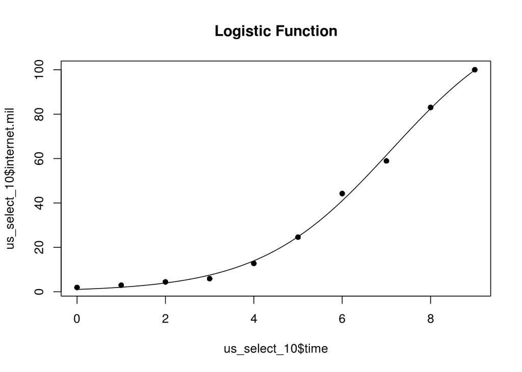

```
## Logistic Fit
##  C =  127.7935
##  a =  121.4
##  b =  1.96391
##  R-squared =  0.99802
```

```r
logisticFit(us_select_10$time, us_select_10$internet.mil)
```

```r
# Based on the prior model parameters, predict the number of internet users in 2006
e <- expFitPred(us_select_10$time, us_select_10$internet.mil, 16)
```

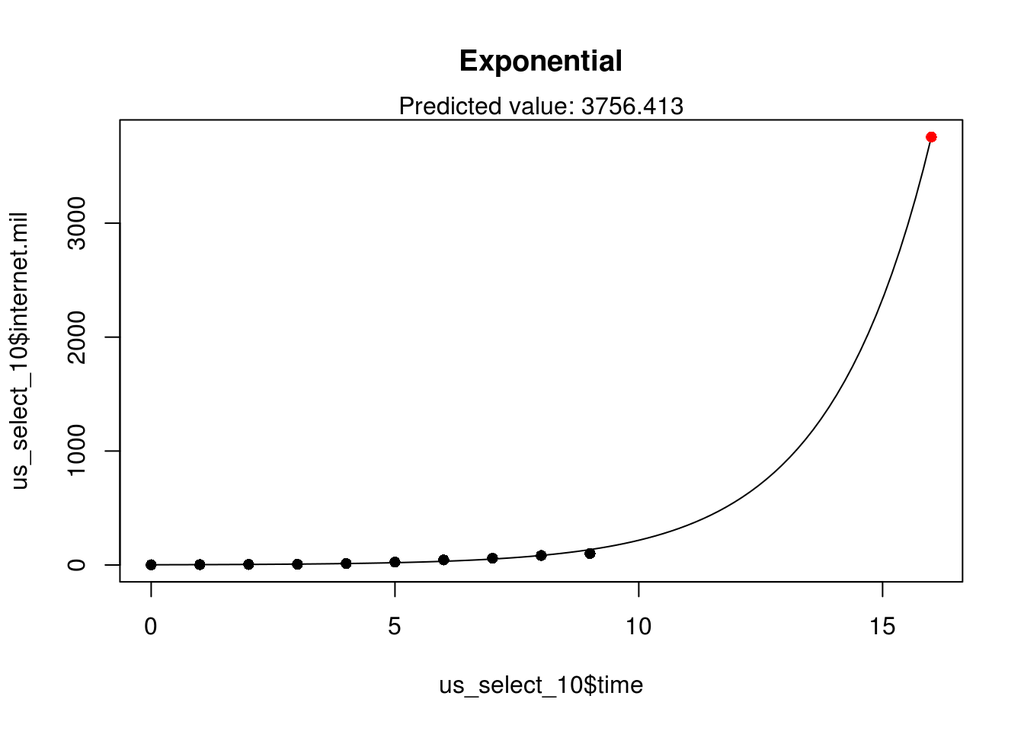

```r
l <- logisticFitPred(us_select_10$time, us_select_10$internet.mil, 16)
```

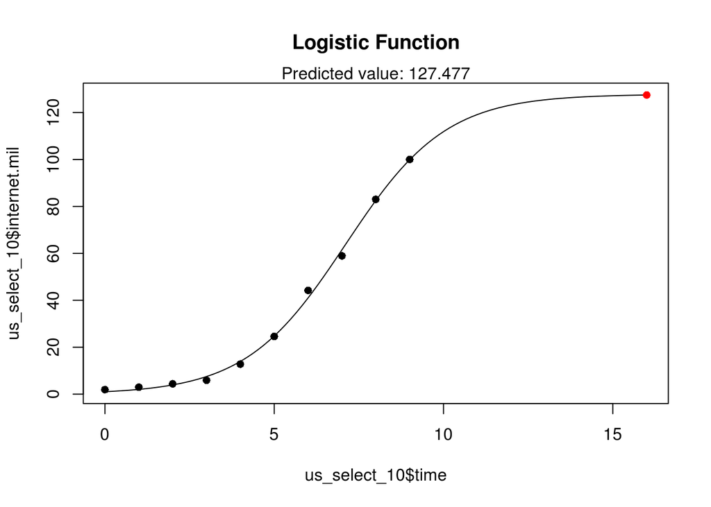

problem 2/2 points (graded) 1) Report the parameters of the exponential model for the number of internet users in the US for years 1990-1999. (Round to 3 decimal places)

a=

1.872 correct 1.872 b=

1.608 correct 1.608 Submit You have used 1 of 1 attempt Some problems have options such as save, reset, hints, or show answer. These options follow the Submit button.

Show Answer Correct (2/2 points) Review problem 1/2 points (graded) 2) Report these parameters of the logistic model for the number of internet users in the US for years 1990-1999. (Round to 1 decimal place)

C=

127794 incorrect127.8 127794 a=

121.4 correct121.4 121.4 Click here for a video explanation of how to answer this question. Submit You have used 1 of 1 attempt Some problems have options such as save, reset, hints, or show answer. These options follow the Submit button.

Show Answer Answers are displayed within the problem Review problem 1/1 point (graded) 3) What was the actual number of internet users (in millions) in the United States in 2006? (Round to 1 decimal place)

205.7 correct 205.7 Submit You have used 1 of 1 attempt Some problems have options such as save, reset, hints, or show answer. These options follow the Submit button.

Show Answer Correct (1/1 point) Review problem 4/4 points (graded) How well did the exponential and logistic models predict the number of internet users in 2006?

4a) The exponential model predicted __________ million users in 2006. The residual was _______.

correct correct Submit You have used 1 of 1 attempt Some problems have options such as save, reset, hints, or show answer. These options follow the Submit button.

Show Answer Correct (4/4 points) Review problem 1/1 point (graded) 5) Based on the model residuals for 2006, which model do you think does a better job of predicting (long-term) the number of internet users?

Both models predict the number of internet users in 2006 equally well. The exponential model. The logistic model. correct Neither model is a good fit for the data. Submit You have used 1 of 1 attempt Some problems have options such as save, reset, hints, or show answer. These options follow the Submit button.

Primary Research Question

problem 6/6 points (graded) Write Your Conclusion

Answer the question and support your answer with statistics:

correctBoth the logistic and exponential models do/does a fairly good job of fitting the pattern of internet usage in the United States from 1990-1999, as shown by R-squared values correctgreater than 0.95. If we look ahead to 2006, however, we see that the correctlogistic model has a better long-term fit. This model predicted correct127.5 million users in 2006, with a smaller residual of correct78.2 million. The correctexponential model predicted far more users than there really were. It appears that the number of new internet users grew rapidly at first but then began to level off over time.

# Lab 6: Worldwide Trends in Internet Usage

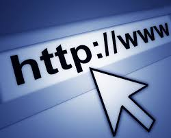

The World Bank is a data collection of information on all the world’s countries. Data is collected by country, and include items such as total population, CO2 emissions, and the number of mobile device subscriptions. We will examine some of the trends in this dataset and interpret the parameters of the fitted models to best describe the change over time.

problem 3/3 points (graded) Review of Exponential and Logistic Models

In this lab, you will use exponential and logistic models to answer a question of interest. Let’s start by remembering how we approach a modeling problem.

1. When choosing between two models with very similar R2 values, what additional statistic should you examine to help you select the best-fitting model?

The sum of squares The residuals correct The value of r the mean and standard deviation of the dependent variable 2) Which parameter represents the rapidity of growth (or change) in both the exponential and the logistic model?

a t C b correct 3) Most biological data will follow a logistic growth model. Why?

The logistic model does a better job at estimating the initial growth rate than the exponential model. The logistic model never decays; it only increases with time. The logistic model takes into account the fact that most growth does not continue indefinitely. correct Submit You have used 1 of 2 attempts Some problems have options such as save, reset, hints, or show answer. These options follow the Submit button.

Save Save Your Answer  
Show Answer Correct (3/3 points) Review Lab Preparation

In this lab you will be working with data from the World Bank.

1. Open RStudio. Make sure you’ve installed the current version of the SDSFoundations package.
2. Type library(SDSFoundations) This will automatically load the data for the labs. 3.Type world <- WorldBankData This will assign the data to your Workspace.

Alternatively, you can follow the steps in the “Importing a Data Frame” R tutorial video, and use the WorldBankData.csv file. (Right-click and “Save As.”) Make sure to name the dataframe “world” when importing.

1. Open RStudio.
2. Click on “Import Dataset” button at the top of the workspace window. Choose “from text file.”
3. Click on the location of the WorldBankData.csv file you just downloaded.
4. Click on the WorldBankData.csv file. Then, click Upload.

Feel free to use the script from the week’s PreLab, which you can modify for use in this Lab.

Analyze the Data

Primary Research Question

Denmark is a high-income country in Europe of about 5.5 million people. What is the best-fitting model for growth of internet usage in Denmark since 1990?

Analysis

Let’s break this question down into the different descriptive statistics that you will need to construct your answer. Be sure that your R output includes all of the following components.

1. Create a variable that represents proportion of the population using the internet (internet users divided by population).
2. Create a subset of the data that only contains data from 1990 onward.
3. Create a new variable that is “years since 1990”.
4. Create two new data frame for the country of interest.
5. Determine the best-fitting model (exponential or logistic) for internet usage in each country from 1990 onward.

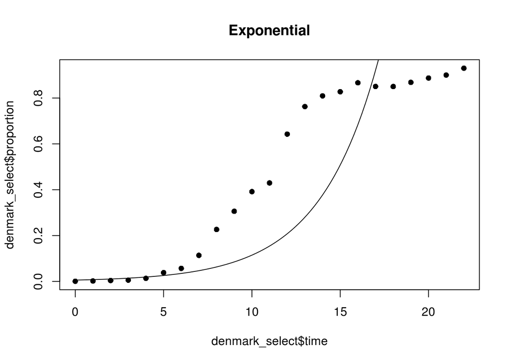

```
## Exponential Fit
##  a =  0.00585
##  b =  1.34666
##  R-squared =  0.80012
```

```r
# Subset data for just the United States and name the new data frame "us"
denmark <- world[world$Country.Code == "DNK",]

# Select the years from 1990 and name the new data frame "us_select"
denmark_select <- denmark[denmark$year >= 1990, ]

# Create a new variable in our datset called internet.mil to make the number of users more interpretable (into millions)
denmark_select$proportion <- denmark_select$internet.users / denmark_select$population

# Create a new variable in our dataset called time that represents "years since 1990"
denmark_select$time <- denmark_select$year - 1990

# Select the first 10 years (from 1990 to 1999) and name the new data frame "us_select_10"
#denmark_select_10 <- denmark_select[denmark_select$time < 10,]

# Use a function to fit an exponential and logistic model for 1990-1999
expFit(denmark_select$time, denmark_select$proportion)
```

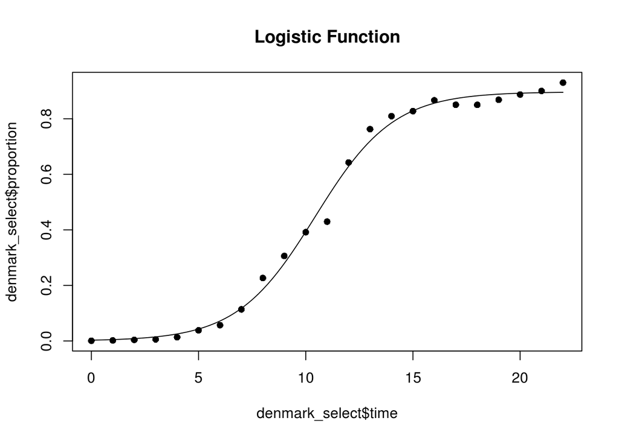

```
## Logistic Fit
##  C =  0.89668
##  a =  308.8345
##  b =  1.73124
##  R-squared =  0.99487
```

```r
logisticFit(denmark_select$time, denmark_select$proportion)
```

```r
# Based on the prior model parameters, predict the number of internet users in 2006
e <- expFitPred(denmark_select$time, denmark_select$proportion, 0)
```

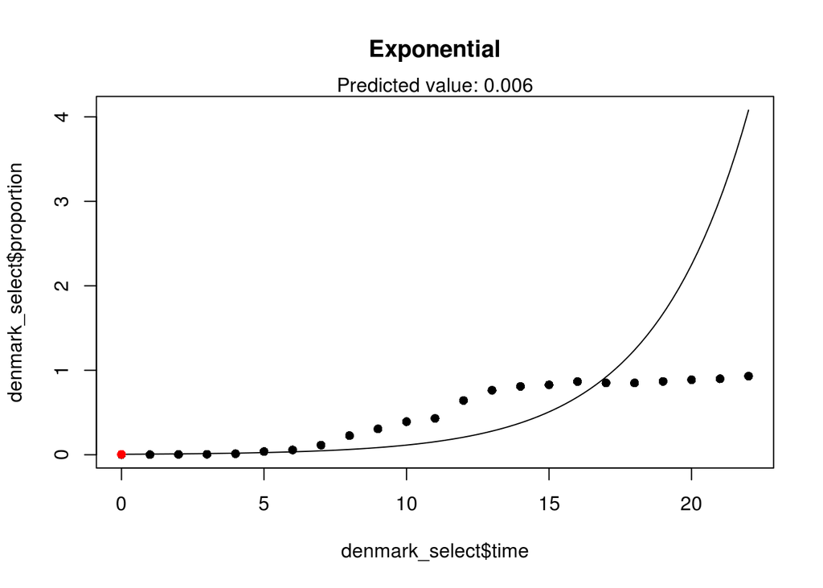

```r
l <- logisticFitPred(denmark_select$time, denmark_select$proportion, 0)
```

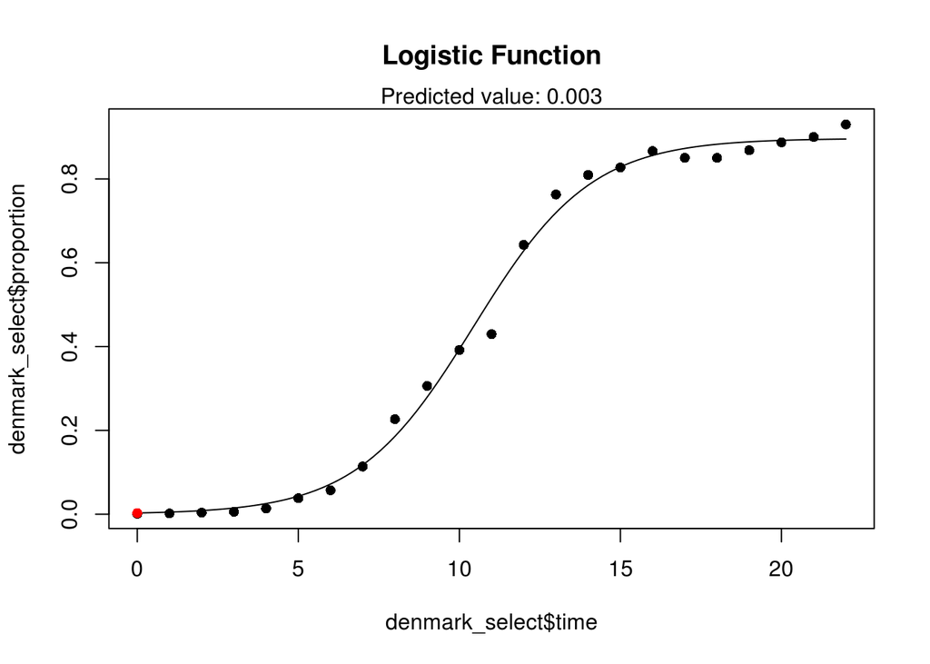

problem 1/3 points (graded) Model Fit Statistics

Report the model fit statistic (R2) for each of the following models. Round to 4 decimal places.

1a) Exponential growth model for Denmark:

0.9932 incorrect.8001 0.9932 1b) Logistic growth model for Denmark:

0.9964 incorrect.9949 0.9964 1c) What is the best-fitting model for growth of internet usage in Denmark from 1990 onward?

logistic correct neither logistic nor exponential exponential Submit You have used 1 of 1 attempt Some problems have options such as save, reset, hints, or show answer. These options follow the Submit button.

Show Answer Answers are displayed within the problem Review problem 0 points possible (ungraded) Exponential Models

Use the exponential model to answer the following questions:

2a) What is the growth factor for the exponential model? (Round to 3 decimal places.)

1.352 incorrect1.347 1.352 2b) What is the percent growth rate of internet use, according to the exponential model? (Round to a whole-number percentage, but report without using “%”)

35 correct35

Submit You have used 1 of 1 attempt Some problems have options such as save, reset, hints, or show answer. These options follow the Submit button.

Show Answer Answers are displayed within the problem Review problem 2/2 points (graded) Logistic Models

Use the logistic model to answer the following questions:

3a) What is the carrying capacity in Denmark? (Round to 4 decimal places.)

0.8966 correct.8967 () 3b) What is the value of b (the growth indicator) in Denmark? (Round to 2 decimal places.)

1.73 correct1.73 () Submit You have used 1 of 1 attempt Some problems have options such as save, reset, hints, or show answer. These options follow the Submit button.

Show Answer Answers are displayed within the problem Review problem 0/2 points (graded) Prediction Using Both Models

4a) In what YEAR does the exponential model predict that 70% of the Denmark population would be using the internet? Use the equation to solve. (Round to a whole number.)

16 incorrect2006 () 4b) In what YEAR does the logistic model predict that 70% of the Denmark population would be using the internet? Use an equation to solve. (Round to a whole number.)

13 incorrect2003 () Submit You have used 1 of 1 attempt Some problems have options such as save, reset, hints, or show answer. These options follow the Submit button.

Primary Research Question

Denmark is a high-income country in Europe of about 5.5 million people. What is the best-fitting model for growth of internet usage in Denmark since 1990?

problem 6/7 points (graded) Write Your Conclusion

Answer the question and support your answer with statistics:

After using both an exponential and a logistic function to model Denmark’s growth of internet usage since 1990, we found that the correctlogistic model fit better with a high R-squared value of correct.995 , compared to an R-squared value of correct.800 for the exponential model. In addition, it is visually clear from the graphs that the logistic model fit the observed data better than the exponential model. All of this suggests that we should trust predictions from the logistic model more than predictions from the exponential model. The exponential model suggests that in 1990, there was a predicted proportion of incorrect.00585 of Denmark’s population that used internet, with the proportion of internet users increasing by a factor of correct1.347 every year after 1990, on average. The logistic model shows that the predicted correctcarrying capacity of the proportion of people who use internet in Denmark was .8967. Since the logistic model fits better, the proportion of internet users in Denmark will probably eventually correctlevel off rather than continuing to grow exponentially.

## Problem Set

Question 1

How has mobile phone usage in Brazil changed since 1995?

1. Create a subset of the world bank data that contains records from Brazil 1995 and later.
2. Change the year variable to be “years since 1995” and update the units of the “mobile.users” variable to millions of users.
3. Use this data to answer the following questions.

Use the “WorldBankData.csv” dataset to answer the following questions. Instructions for installing “WorldRecords.csv” can be found under the Examine the Data unit in this week’s Pre-Lab section.

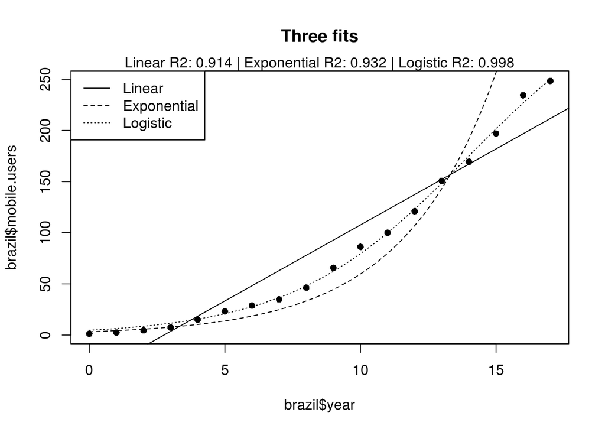

```r
brazil <- world[world$Country.Code == "BRA" & world$year >= 1995,]
brazil$year <- brazil$year - 1995
brazil$mobile.users <- brazil$mobile.users / 1000000

tripleFit(brazil$year, brazil$mobile.users)
```

```r
l <- logisticFitPred(brazil$year, brazil$mobile.users, 2025)
```

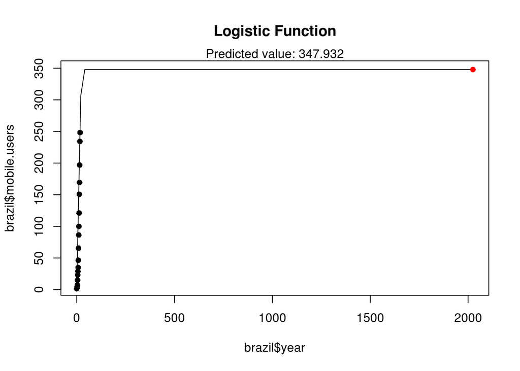

problem 1/1 point (graded) 1a. Use RStudio to find the number of mobile users in Brazil (in millions) in 2000. (Round to 2 decimal places.)

23.19 correct 23.19 Submit You have used 1 of 1 attempt Some problems have options such as save, reset, hints, or show answer. These options follow the Submit button.

Show Answer Correct (1/1 point) Review problem 1/1 point (graded) 1b. In what year did Brazil first record more than 100 million mobile users?

2007 correct 2007 Submit You have used 1 of 1 attempt Some problems have options such as save, reset, hints, or show answer. These options follow the Submit button.

Show Answer Correct (1/1 point) Review problem 0 points possible (ungraded) 1c. Generate a scatterplot and fit a linear, exponential and logistic model to the data. Which model best describes the increase in mobile users in Brazil since 1995?

Exponential Model Linear Model Logistic Growth Model correct Submit You have used 1 of 1 attempt Some problems have options such as save, reset, hints, or show answer. These options follow the Submit button.

Show Answer Correct Review problem 1/1 point (graded) 1d. What proportion of the variation in mobile users is explained by years since 1995 in the best‐fitting model? (Round to 3 decimal places.)

Show Answer Correct (1/1 point) Review problem 0/1 point (graded) 1e. Using the best‐fitting model, predict the number of mobile users (in millions) in Brazil in 2025. (Round to a whole number.)

347.932 incorrect345 347.932

Question 2

Records at the Center for Disease Control show that the total number of flu cases in Spring, 2009 looked like this:

Date Day Flu Cases April 27 0 73 April 28 1 105 April 29 2 137 April 30 3 257 May 1 4 367 May 2 5 658 May 3 6 898 May 4 7 1,085 May 5 8 1,490 May 6 9 1,893 An initial examination of the data showed that both an exponential and a logistic growth model fit the data well:

Exponential Model Logistic Growth Model a = 76.64 C = 3,273.31 b = 1.46 a = 43.59 R-squared = 0.984 b = 1.57 R-squared = 0.996 Use the data from the TABLE of Models to answer the following questions.

problem 0/1 point (graded) 2a. Looking at the raw data, what is the rate of change in flu cases from April 30 to May 1? (Report as a proportion rounded to 2 decimal places.)

110 incorrect.43 110 Submit You have used 1 of 1 attempt Some problems have options such as save, reset, hints, or show answer. These options follow the Submit button.

Show Answer Answers are displayed within the problem Review problem 0/1 point (graded) 2b. What is the growth rate for the flu, according to the exponential model? (Report as a proportion rounded to 2 decimal places.)

1.46 incorrect.46 1.46 Submit You have used 1 of 1 attempt Some problems have options such as save, reset, hints, or show answer. These options follow the Submit button.

Show Answer Answers are displayed within the problem Review problem 1/1 point (graded) 2c. Predict the number of cases of flu on Day 14 (when “Day” is equal to 14), using the exponential model. (Round to a whole number, without a comma)

15325 correct 15325 Submit You have used 1 of 1 attempt Some problems have options such as save, reset, hints, or show answer. These options follow the Submit button.

Show Answer Correct (1/1 point) Review problem 1/1 point (graded) 2d. Using the logistic model, predict the total number of flu cases on Day 14. (Round to a whole number, without a comma.)

3034 correct 3034 Submit You have used 1 of 1 attempt Some problems have options such as save, reset, hints, or show answer. These options follow the Submit button.

Show Answer Correct (1/1 point) Review problem 0/1 point (graded) 2e. The actual number of flu cases on Day 14 was 4,379. Find the residual of the exponential model prediction. (Round to zero decimal places, without a comma.)

10946 incorrect-10946 10946 Submit You have used 1 of 1 attempt Some problems have options such as save, reset, hints, or show answer. These options follow the Submit button.

Show Answer Answers are displayed within the problem Review problem 1/1 point (graded) 2f. What is the residual of the logistic model prediction for Day 14? (Round to a whole number, without a comma.)

1345 correct 1345 Submit You have used 1 of 1 attempt Some problems have options such as save, reset, hints, or show answer. These options follow the Submit button.

Show Answer Correct (1/1 point) Review problem 5/5 points (graded) Based on the residuals of both models, what conclusion would you reach? Fill in the missing blanks.

Question 3

3. Yellowstone National Park began a project to restore its native wolf population in the mid 1990’s. Below are the number of wolves soon after the start of the project:

Year Years since Project Began Number of Wolves 1996 1 25 1998 3 45 problem 1/1 point (graded) 3a. Researchers fit a linear model to the wolf data. Using this model, how many wolves were being added to the park each year? (Round to a whole number.)

10 correct 10 Submit You have used 1 of 1 attempt Some problems have options such as save, reset, hints, or show answer. These options follow the Submit button.

Show Answer Correct (1/1 point) Review problem 1/1 point (graded) 3b. According to their linear model, what was the size of the original wolf population when the project began?

15 correct 15 Submit You have used 1 of 1 attempt Some problems have options such as save, reset, hints, or show answer. These options follow the Submit button.

Show Answer Correct (1/1 point) Review problem 0/1 point (graded) 3c. Another researcher assumed that the wolves would experience exponential growth because there were no predators. He fit an exponential model to this data. What is the growth factor for this model? (Round to 2 decimal places.)

1.875 incorrect1.34 1.875 Submit You have used 1 of 1 attempt Some problems have options such as save, reset, hints, or show answer. These options follow the Submit button.

Show Answer Answers are displayed within the problem Review problem 1/1 point (graded) 3d. What is the annual growth rate of these wolves each year, according to this model? (Report as a proportion rounded to 2 decimal places.)

0.34 correct 0.34 Submit You have used 1 of 1 attempt Some problems have options such as save, reset, hints, or show answer. These options follow the Submit button.

Show Answer Correct (1/1 point) Review problem 1/1 point (graded) 3e. Assuming exponential growth, find the initial number of wolves when the project began. Use your rounded answer from the previous question. (Round to a whole number.)

19 correct 19 Submit You have used 1 of 1 attempt Some problems have options such as save, reset, hints, or show answer. These options follow the Submit button.

Show Answer Correct (1/1 point) Review problem 1/1 point (graded) 3f. By 2002, there were 147 wolves in Yellowstone Park. Which model was determined to fit the data better?

Exponential correct Linear Neither model appears to fit well Submit You have used 1 of 1 attempt Some problems have options such as save, reset, hints, or show answer. These options follow the Submit button.

Show Answer Correct (1/1 point) Review problem 0/1 point (graded) 3g. Using the best‐fitting model, how many years must pass before there are more than 325 wolves in Yellowstone? (Round to a whole number.)

2006 incorrect10 2006

Question 4

4. A group of hedgehogs was released in the south‐Austin area. Each year, the size of the population was recorded. Their population growth over time was modeled with a logistic growth curve. The model fit was 0.972.

Here are the model parameters:

C = 2,000

a = 152.10

b = 2.17

problem 1/1 point (graded) 4a. According to this model, what will be the maximum number of hedgehogs in South Austin?

2000 correct 2000 Submit You have used 1 of 1 attempt Some problems have options such as save, reset, hints, or show answer. These options follow the Submit button.

Show Answer Correct (1/1 point) Review problem 1/1 point (graded) 4b. What was the size of the hedgehog population when the growth rate began to slow down?

1000 correct 1000 Submit You have used 1 of 1 attempt Some problems have options such as save, reset, hints, or show answer. These options follow the Submit button.

Show Answer Correct (1/1 point) Review problem 0/1 point (graded) 4c. How many years had passed when the population growth rate began to slow down? (Round to 1 decimal place.)

7 incorrect6.5 7 Submit You have used 1 of 1 attempt Some problems have options such as save, reset, hints, or show answer. These options follow the Submit button.

Show Answer Answers are displayed within the problem Review problem 1/1 point (graded) 4d. The hedgehogs were released in South Austin in 2001. How many hedgehogs were living in South Austin by 2010, according to the model? (Round to a whole number.)

1750 correct 1750